# multicrispr: find offtarget-free cas9 sites for many target ranges

Aditya M Bhagwat

16 September 2019

# Contents

The `multicrispr` package facilitates the design of a multi-locus crispr/cas9 library, offering a set of intuitive functions:

- `read_bed`: read bedfile into [GenomicRanges::GRanges](https://bioconductor.org/packages/release/bioc/html/GenomicRanges.html) object
- `flank_fourways`: obtain flank ranges (if they are to be targeted)
- `find_specfic_cas9s`: find offtarget-free cas9 sequences (and ranges)
- `score_cas9s`: score cas9 sequences for binding efficiency.

# 1 Read target ranges

```r
library(magrittr)
library(multicrispr)
bedfile      <- system.file('extdata/SRF.bed', package = 'multicrispr')
bsgenome     <- BSgenome.Mmusculus.UCSC.mm10::Mmusculus
targetranges <- read_bed(bedfile, bsgenome)
    #   Read C:/Users/abhagwa/Documents/multicrispr/inst/extdata/SRF.bed
    #       Convert 0 -> 1-based
    #       Ranges: 1974 ranges on 21 chromosomes
    #               16 NT wide
    #               1 - 36535761 NT apart
```

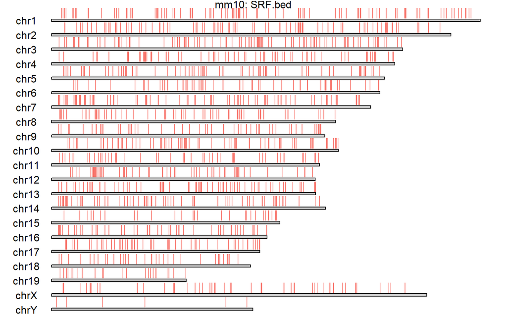

# 2 Flank

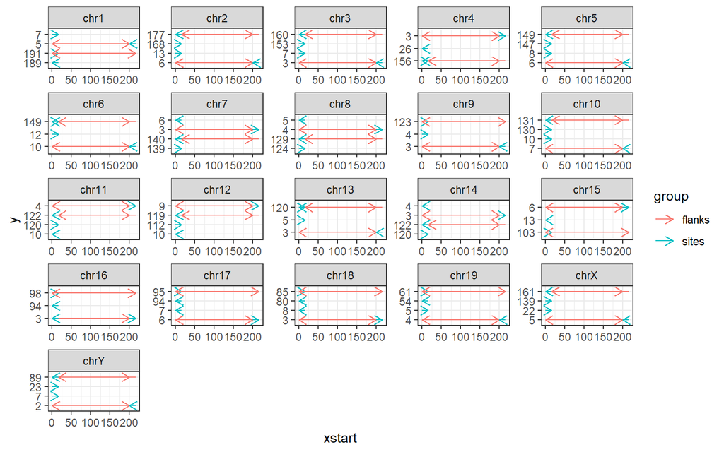

```r
targetranges %<>% flank_fourways()
    #   Flank fourways
    #       1974 left  flanks : [start-200, start-1]
    #       1974 right flanks : [end+1, end+200]
    #       3948 combined (left + right)
    #       7896 after adding strand-complements
    #       7306 after merging overlaps
```

# 3 Find offtarget-free cas9s

```r
cas9ranges <- find_specific_cas9ranges(targetranges, mismatch = 0)
    #   Find N{20}NGG cas9seqs
    #       Rm 10 targetranges with no cas9sites
    #       9923 cas9 seqs across 33607 targetranges
    #   Find cas9seq hits
    #       with 0 mismatch(es)
    #           Count 0-mismatch hits in targetranges: 2.5 mins
    #           Count 0-mismatch hits in genome      : 2 mins
    #           Keep 6677/9923 target-specific cas9seqs
    # Returning 6677 cas9seqs across 6964 ranges
```

# 4 Score cas9s

Doench et al. (2014)’s “ruleset1” for scoring cas9 sequences is readily available:

```r
cas9ranges$score_rs1 <- score_cas9ranges(cas9ranges, ruleset = 1)
    #   Score contextseqs (4-23-3) with ruleset1
```

The improved “ruleset2” (Doench, 2016) is also accessible, but requires for the python module [azimuth](https://github.com/MicrosoftResearch/Azimuth%5D) to be installed and accessible as a python binary, virtual environment, or conda environment. The code chunk below shows how to score using ruleset 2 if azimuth was installed in the condaenv “default”. It also shows the common operation of filtering for ruleset2 score values above 0.4.

```r
python_available <- assertive.reflection::is_unix() &
                    reticulate::py_module_available('azimuth')
if (python_available){
  cas9ranges$score_rs2 <- score_cas9s(
                            cas9ranges, ruleset = 2, condaenv = 'default')

  message('\tFilter for scores > 0.4')
  cas9ranges %<>% extract(cas9ranges$score > 0.4)
  cmessage('\t\t%d cas9 seqs across %d ranges',
            length(unique(cas9ranges$seqs)),
            length(cas9ranges))
}
```

# 5 References

Doench et al. (2014). Rational design of highly active sgRNAs for CRISPR-Cas9-mediated gene inactivation. Nature Biotechnology, 32(12), doi:10.1038/nbt.3026

Doench et al. (2016). Optimized sgRNA design to maximize activity and minimize off-target effects of CRISPR-Cas9. Nature Biotechnology, 34(7), doi:10.1038/nbt.3437